# All homeworks

BA23001021 Yulin Zhou

2023-11-29

# HW0

# 例一

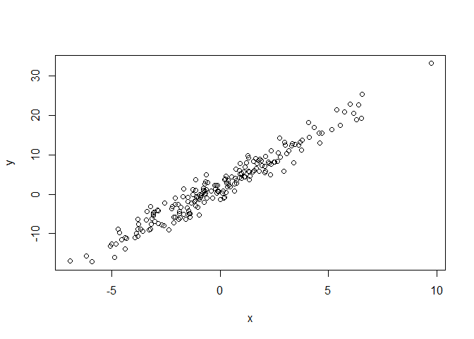

```r
set.seed(123)
n <- 200
x <- rnorm(n, mean = 0, sd = 3)
y <- 2 + 3 * x + rnorm(n, mean = 0, sd = 2)
plot(x, y)
```

对数据进行线性拟合，结果如下：

```r
fit <- lm(y~x)
summary(fit)
```

```
##
## Call:
## lm(formula = y ~ x)
##
## Residuals:
##     Min      1Q  Median      3Q     Max
## -4.9584 -1.3124 -0.0681  1.3607  5.0373
##
## Coefficients:
##             Estimate Std. Error t value Pr(>|t|)
## (Intercept)  2.08374    0.14115   14.76   <2e-16 ***
## x            2.98050    0.05001   59.60   <2e-16 ***
## ---
## Signif. codes:  0 '***' 0.001 '**' 0.01 '*' 0.05 '.' 0.1 ' ' 1
##
## Residual standard error: 1.996 on 198 degrees of freedom
## Multiple R-squared:  0.9472, Adjusted R-squared:  0.9469
## F-statistic:  3552 on 1 and 198 DF,  p-value: < 2.2e-16
```

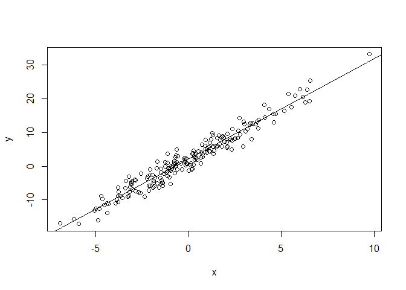

```r
plot(x, y)
abline(a = fit$coefficients[1], b = fit$coefficients[2])
```

# 例二

从airquality数据集中生成测试表与测试图。

```r
knitr::kable(head(airquality), align = "c", caption = "测试表-airquality")
```

测试表-airquality

| Ozone | Solar.R | Wind | Temp | Month | Day |
| --- | --- | --- | --- | --- | --- |
| 41 | 190 | 7.4 | 67 | 5 | 1 |
| 36 | 118 | 8.0 | 72 | 5 | 2 |
| 12 | 149 | 12.6 | 74 | 5 | 3 |
| 18 | 313 | 11.5 | 62 | 5 | 4 |
| NA | NA | 14.3 | 56 | 5 | 5 |
| 28 | NA | 14.9 | 66 | 5 | 6 |

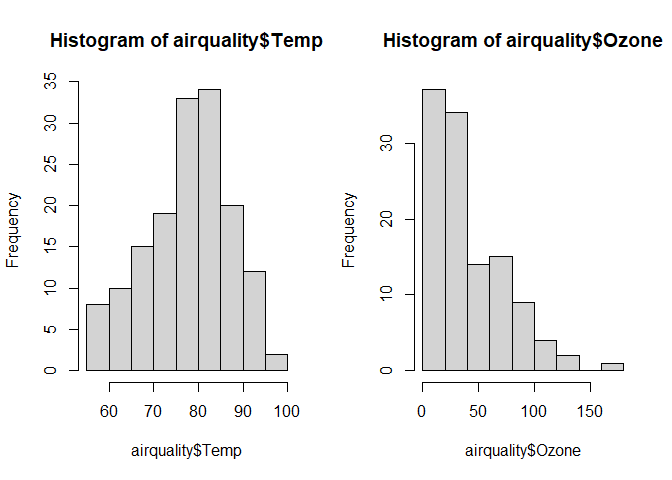

```r
par(mfrow = c(1,2))
hist(airquality$Temp)
hist(airquality$Ozone)
```

# 例三

按照
$$X\sim U(-2\pi, 2\pi),
\\Y = \sin(X) + \epsilon,
\\\epsilon\sim N(0,1)$$
生成数据，样本量$n = 1000$。 使用LOESS方法对数据进行曲线拟合。 结果如下：

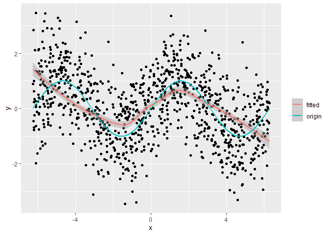

```r
library(ggplot2)
n <- 1000
x <- runif(n, -2 * pi, 2 * pi)
y <- sin(x) + rnorm(n, 0, 1)

p <- ggplot(
  data.frame(x = x, y = y),
  aes(x, y)) +
  geom_point() +
  stat_smooth(
    formula = y ~ x,
    method = loess,
    aes(colour = "fitted"),
    linewidth = 1
    ) +
  stat_function(
    fun=sin,
    aes(colour = "origin"),
    linewidth = 1
    ) +
  guides(colour=guide_legend(title=NULL))
p
```

# HW1

## 课后习题

利用逆变换法复现replace = TRUE时函数sample的功能。

### 解答

**代码实现：**

```r
my.sample <- function(x, size, prob = NA){

  #默认概率均分
  if(length(prob) == 1) if(is.na(prob)){
    prob = rep(1, length(x)) / length(x)
  }

  if(
    sum(prob) != 1 || sum(prob < 0) > 0
  ) stop("invalid prob")

  df <- c(0, cumsum(prob))#分布函数
  u <- runif(size, 0, 1)
  location <- sapply(u, FUN = df.inv, df)

  return(x[location])
}

df.inv <- function(u, df){#分布函数的逆
  uu <- u < df
  a <- uu[-1]
  b <- (!uu)[-length(df)]

  return(which.max(a * b))
}
```

**测试：**

```r
set.seed(123)

x <- c("a", "c", "f", "x", "z")
size <- 10000
prob <- c(0.1, 0.3, 0.2, 0.15, 0.25)

y <- my.sample(x, size, prob)

freq <- integer(length(x))

for(i in 1:5){
  freq[i] <- sum(y == x[i]) / size
}

print(freq - prob)
```

```
## [1] -0.0010 -0.0016  0.0073  0.0018 -0.0065
```

**样本频率对比原始频率**

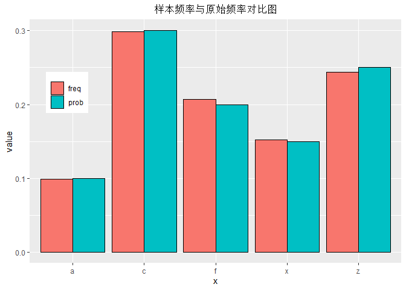

可见my.sample生成样本的频率与prob非常接近。

## Exercise 3.2

标准Laplace分布的密度为$f(x) = \frac{1}{2}e^{-|x|}, x\in\mathbb{R}$。 使用逆变换法从此分布中生成容量为$1000$的样本， 并使用本章出现过的一种方法来比较此样本与目标分布。

### 解答

$F(x) = \int_0^tf(u)\text{d}u = \frac{1}{2}e^x1_{\{x<0\}} + (1-\frac{1}{2}e^{-x})1_{\{x\geq 0\}}$。 因此
$$F^{-1}(u) =
\left\{
\begin{aligned}
&\log(2u), &0<u<1/2
\\&-\log(2(1-u)). &1/2\leq u < 1
\end{aligned}
\right.$$

**代码实现**

```r
laplace <- function(size){
  u <- rbind(runif(size, min = 0, max = 1))

  x <- integer(length(u))
  uu <- u < 0.5
  x[uu] <- log(2 * u[uu])
  x[!uu] <- -log(2 * (1 - u[!uu]))

  return(x)
}

set.seed(123)
x <- laplace(1000)
```

**样本频率对比目标密度**

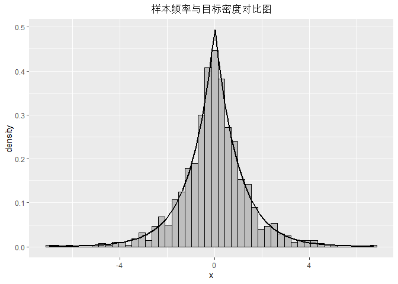

可见样本频率与目标密度非常接近。

**样本累积经验分布对比目标分布**

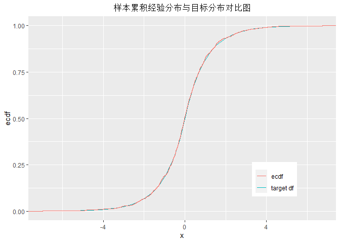

同样非常接近。

## Exercise 3.7

### 解答

${\rm Beta}(a,b)$的密度函数为
$$f(x;a,b) = \frac{1}{{\rm B}(a,b)} x^{a-1}(1-x)^{b-1}1_{[0, 1]}(x).$$
$a,b \geq 1$时，对$x$求导，可知其最大值在$x = \frac{a-1}{a+b-2}$处达到， 为
$$M(a,b) = \frac{(a-1)^{a-1}(b-1)^{b-1}}{{\rm B}(a,b)(a+b-2)^{a+b-2}}.$$
因此令$g(x) = 1_{[0, 1]}$为$U(0, 1)$的密度函数，$c = M(a,b)$， 即可使用接受-拒绝法生成样本。

$0 < a < 1$或$0 < b < 1$时，最大值为$\infty$，无法使用接受-拒绝法。

**代码实现**

```r
beta.single <- function(a, b, c){
  while(TRUE){
    u <- runif(1, 0, 1)
    y <- runif(1, 0, 1)
    if(
      u <= y^(a-1) * (1-y)^(b-1) / c
    ) return(y)
  }
}

beta.sample <- function(size, a, b){
  if(a < 1 || b < 1) stop("invalid a or b")

  c <- (a-1)^(a-1) * (b-1)^(b-1) / (a+b-2)^(a+b-2)
  x <- sapply(rep(a, size), FUN = beta.single, b, c)

  return(x)
}

set.seed(123)
x <- beta.sample(1000, 3, 2)
```

**样本频率对比理论密度**

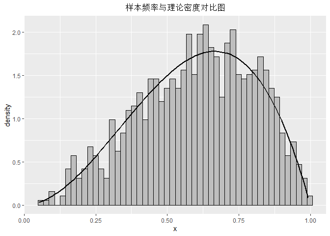

两者很接近。

## Exercise 3.9

编写函数来生成此分布，并对比样本频率与理论密度。

### 解答

**代码实现**

```r
epane <- function(size){
  U1 <- runif(size, min = -1, max = 1)
  U2 <- runif(size, min = -1, max = 1)
  U3 <- runif(size, min = -1, max = 1)

  uu <- abs(U3) > abs(U1) & abs(U3) > abs(U2)
  x <- integer(size)
  x[uu] <- U2[uu]
  x[!uu] <- U3[!uu]
}

set.seed(123)
x <- epane(100000)
```

**样本频率对比理论密度**

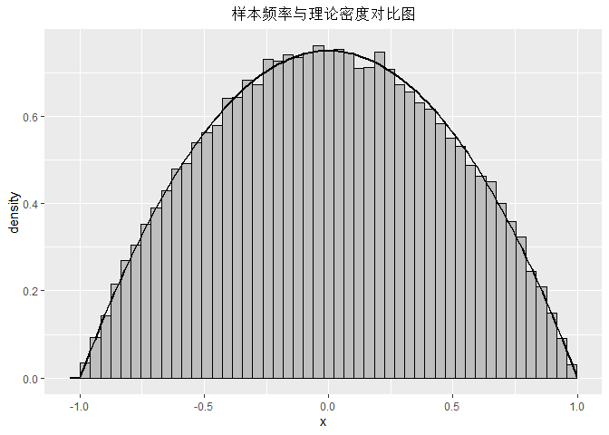

两者非常接近。

## Exercise 3.10

证明3.9中的方法生成的变量就服从$f_e$。

### 证明：

3.9中的方法等价于： 从$U(0,1)$中i.i.d.生成$X_1,X_2,X_3$，随机选出一个不是最大的，记为$Y$； 令$\delta$为$\{-1, 1\}$的等概率两点分布，与$X_1,X_2,X_3$独立； 最终输出$X=\delta\cdot Y$。

$\forall x\in [0,1]$，$Y\leq x$可分为两种情况：

1. $X_1,X_2,X_3$至少有两个$\leq x$。 概率为$\binom{3}{2}x^2(1-x) + \binom{3}{3}x^3 = 3t^2 - 2t^3$。
2. $X_1,X_2, X_3$中有且只有一个$\leq x$，且刚好被选到。 概率为$0.5\cdot\binom{3}{1}x(1-x)^2 = \frac{3}{2}(x^3-2t^2+x)$。

相加即得
$${\rm P}(Y\leq x) = \frac{3}{2}x - \frac{1}{2}x^3,\\
f_Y(x) = \frac{3}{2}(1-x^2)1_{[0,1]}(x).$$
从而
$$f_X(x) = \frac{3}{4}(1-x^2) 1_{[-1,1]}(x)=f_e(x).$$

# HW2

## 课后习题

在Buffon实验中，使用$\delta$法，找到最小化$\hat\pi$的渐近方差的$\rho = \frac{l}{d}$。 取三个不同的$\rho$值（包括$\rho_{\rm min}$），使用Monte Carlo法来验证（$n = 10^6$，样本量$K=100$）。

### 解答

设$X_i\sim U(0, d/2), Y_i \sim U(0, \pi/2), i=1,...,m$，且独立。 令$Z_i = 1_{\{\sin Y_i \geq 2X_i \}}$， 则$Z_i, i=1,..,m$ i.i.d，且$n = \sum_{i=1}^m Z_i$。

${\rm E}Z_i = \frac{2\rho}{\pi}$， ${\rm Var}(Z_i) = \frac{2\rho}{\pi} - \left(\frac{2\rho}{\pi}\right)^2$， 于是
$${\rm E}\hat p = \frac{2\rho}{\pi},\\
{\rm Var}(\hat p) = \frac{2\rho}{m\pi} \left(1-\frac{2\rho}{\pi}\right).$$
由$\delta$法，

$${\rm Var}(\sqrt{m} (\hat \pi - \pi)) \approx 4\rho^2 \frac{1}{(2\rho /
\pi)^4} \frac{2\rho}{m\pi} \left(1-\frac{2\rho}{\pi}\right) =
\frac{\pi^3}{2\rho} - \pi^2,$$
最小值在$\rho = 1$处达到，为$\frac{\pi^3}{2} - \pi^2$。

选取$\rho = 0.2, 0.5, 1$，模拟如下：

```r
set.seed(12345)
d <- 1; m <- 1e6
rho <- c(0.2, 0.5, 1)

pihat.var <- integer(0)
for(rr in rho){
  l <- d * rr
  pihat <- integer(0)
  for(i in 1:100){
    X <- runif(m,0,d/2)
    Y <- runif(m,0,pi/2)
    pihat <- c(pihat, 2*l/d/mean(l/2*sin(Y)>X))
  }
  pihat.var <- c(pihat.var, m * var(pihat))
}

pihat.var
```

```
## [1] 74.393564 19.071414  4.734696
```

理论方差：

```r
pi^3 / 2 / rho - pi^2
```

```
## [1] 67.646087 21.136672  5.633534
```

两者下降趋势一致，但具体数值有一定差距。

## Exercise 5.6

### 解答

${\rm E}e^U ={\rm E}e^{1-U}= e-1$，${\rm Var}(e^U) = {\rm Var}(e^{1-U}) = \frac{-e^2+4e-3}{2}$，于是

$${\rm Cov}(e^U, e^{1-U}) = \int_0^1 (e^x-e+1) (e^{1-x}-e+1){\rm d}x = -
e^2 + 3e - 1,\\
{\rm Var}(e^U + e^{1-U}) = 2{\rm Var}(e^U) + 2{\rm Cov}(e^U, e^{1-U}) =
-3e^2 + 10e - 5.$$
相比简单MC，使用样本量缩减至一半的对偶变量法， 方差减小了$\frac{5e^2-16e+7}{-e^2+4e-3} \approx 93.534\%$。

## Exercise 5.7

分别使用简单MC与对偶变量法来估计5.6中的$\theta$，并计算样本方差减小的百分比。 将结果与理论值进行对比。

### 解答

估计$\theta$：

```r
set.seed(123)
n <- 1e6
u <- runif(n)

theta.mc <- mean(exp(u))#简单MC

u <- u[1:(n/2)]#对偶变量法
theta.ant <- mean((exp(u) + exp(1-u)) / 2)

print(c(theta.mc, theta.ant))
```

```
## [1] 1.717553 1.718347
```

估计方差减少：

```r
set.seed(123)
n <- 1e6

var.mc <- integer(100)
var.ant <- integer(100)

for(i in 1:100){
  u <- runif(n)
  var.mc[i] <- var(exp(u) / n)#简单MC

  u <- u[1:(n/2)]#对偶变量法
  var.ant[i] <- var((exp(u) + exp(1-u)) / n)
}

mean(1 - var.ant / var.mc)
```

```
## [1] 0.9353398
```

与理论值$93.534%$非常接近。

# HW3

## 课后习题

在分层采样法中，
$${\rm Var}(\hat\theta^M) = \frac{1}{Mk}\sum_{i=1}^k \sigma_i^2 + {\rm
Var}(\theta_I) = {\rm Var}(\hat\theta^S) + {\rm Var}(\theta_I),$$
其中$\theta_i = {\rm E}(g(U)|I=i)$，$\sigma_i^2 = {\rm Var}(g(U)|I=i)$。

假设$g$在$(a,b)$上连续， 证明$b_i - a_i\rightarrow 0$时 ${\rm Var}(\hat{\theta}^S)/{\rm Var}(\hat{\theta}^M)\rightarrow 0$。

### 证明

由条件期望公式， ${\rm E}(\theta_I) = {\rm E}({\rm E}(g(U)|I=i)) = {\rm E}(g(U)) = \theta$。

$\forall \epsilon > 0$，$\exists \delta > 0$ s.t. $|g(x) - g(y)| < \epsilon \ \forall |x-y| < \delta$。 因此$b_i - a_i<\delta$时，$|\theta_i - g(a_i)| < \epsilon$，$|\theta_i - \theta| < |g(a_i)-\theta| + \epsilon$。

由$a_i$的定义， $\frac{1}{k}\sum_{i=1}^k(g(a_i)-\theta)^2 \rightarrow {\rm Var}(g(U))$， 从而${\rm Var}(\theta_I)\rightarrow {\rm Var}(g(U))$。 而${\rm Var}(\hat\theta^M)\rightarrow {\rm Var}(g(U))$， 因此${\rm Var}(\hat{\theta}^S)/{\rm Var}(\hat{\theta}^M)\rightarrow 0$。

## Exercise 5.13

找到两个支撑在$(1,\infty)$上，且“接近”
$$g(x) = \frac{x^2}{\sqrt{2\pi}}e^{-x^2/2}1_{\{x>1\}}$$
的重要性函数$f_1$与$f_2$。 假设要使用重要性采样来估计$\int_1^\infty g(x){\rm d}x$， 指出并解释使用哪个$f$的方差更小。

### 解答

取$f_1(x) = \frac{2}{\sqrt{2\pi}}e^{-(x-1)^2/2}$，$f_2(x) = e^{-x+1}$。 $g,f_1,f_2$的图像如下：

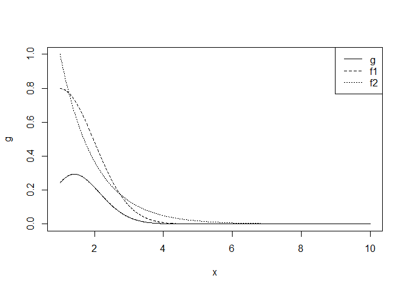

```r
x <- seq(1, 10, 0.01)
g <- x^2 * exp(-x^2/2) / sqrt(2*pi)
f1 <- 2*exp(-(x-1)^2/2) / sqrt(2*pi)
f2 <- exp(-x+1)
plot(x, g, type = "l", ylim = c(0, 1))
lines(x, f1, lty = 2)
lines(x, f2, lty = 3)
legend(
  "topright",
  legend = c("g", "f1", "f2"), lty = 1:3
)
```

$g/f$越接近常数，模拟得到估计的方差就越小。

下图为$g/f_i$的图像：

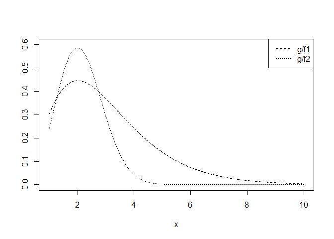

```r
plot(x, g/f1, type = "l",
     ylim = c(0, 0.6), lty = 2, ylab = "")
lines(x, g/f2, lty = 3)
legend(
  "topright",
  legend = c("g/f1", "g/f2"), lty = 2:3
)
```

$g/f_1$更接近常数，因此方差可能更小。

## Exercise 5.14

使用重要性采样法来估计5.13中的$\int_1^\infty g(x){\rm d}x$。

### 解答

取$f$为5.13中的$f_1$。

```r
set.seed(123)

m <- 1e4
num.rep <- 1e3
mc <- numeric(num.rep)

for(i in 1:num.rep){
  x <- abs(rnorm(m, 0, 1)) + 1
  g <- x^2 * exp(-x^2/2) / sqrt(2*pi)
  f <- 2*exp(-(x-1)^2/2) / sqrt(2*pi)

  mc[i] <- mean(g/f)
}

c(mean(mc), var(mc))
```

```
## [1] 4.006229e-01 1.949455e-07
```

对比实际值：

```r
g <- function(x) x^2 * exp(-x^2/2) / sqrt(2*pi)
integrate(g, lower = 1, upper = Inf)
```

```
## 0.400626 with absolute error < 5.7e-07
```

两者非常接近。

## Exercise 5.15

实现例5.13中的分层重要性采样法，并与例5.10做对比。 要估计的量为

$$\int_0^1 \frac{e^x}{1+x^2}{\rm d}x.$$

### 解答

代码如下，输出估计及其方差：

```r
set.seed(123)

M <- 1e4; k <- 5
xx <- seq(0, 1, 1/k)

theta.hat <- theta.var <- numeric(k)
for(i in 1:k){
  u <- runif(M/k, min = xx[i], max = xx[i+1])
  x <- -log(1 - (1 - exp(-1)) * u)

  f <- (k/(1-exp(-1))) * exp(-x)
  g <- exp(-x) / (1+x^2)
  theta.hat[i] <- mean(g/f)
  theta.var[i] <- var(g/f)
}

c(sum(theta.hat), mean(theta.var))
```

```
## [1] 5.250139e-01 1.704006e-05
```

标准误差为

```r
sqrt(mean(theta.var))
```

```
## [1] 0.004127961
```

相比5.10中的各结果都要小得多。

## Exercise 6.5

假设使用$95\%$的$t$区间来估计非正态数据的均值， 则此区间包含均值的概率不一定为$95\%$。 使用MC来估计此区间包含样本量为$20$的$\chi^2(2)$数据的均值的概率， 并与例6.6做对比。

### 解答

```r
set.seed(123)

num.rep <- 1e4; n <- 20
t0 <- qt(c(0.05/2, 1 - 0.05/2), df = n-1)

tt <- matrix(NA, nrow = num.rep, ncol = 2)
for(i in 1:num.rep){
  x <- rchisq(n, df = 2)
  tt[i, ] <- mean(x) + t0 * sd(x) / sqrt(n)
}

mean(tt[,1] < 2 & tt[,2] > 2)
```

```
## [1] 0.9218
```

远高于例6.6中的包含概率$77.3\%$。

## Exercise 6.A

使用MC模拟来探究：当样本非正态时，$t$-检验的经验第一类错误是否接近名义检验水准$\alpha$。 讨论以下三种样本： (i) $\chi^2(1)$，(ii) $U(0,2)$，(iii) ${\rm Exp}(1)$。 检验$H_0: \mu = \mu_0$对$H_1:\mu\neq \mu_0$。

### 解答

生成样本：

```r
# 1: chi方 2: 均匀 3: 指数
samp.generate <- function(num.rep, size){
  samp <- array(NA, dim = c(num.rep, size, 3))
  for(i in 1:num.rep){
    samp[i, , 1] <- rchisq(size, df = 1)
    samp[i, , 2] <- runif(size, min = 0, max = 2)
    samp[i, , 3] <- rexp(size, rate = 1)
  }
  saveRDS(samp, file = "samp.rds")
}
```

样本分析：

```r
samp.analysis <- function(filename, alpha){
  samp <- readRDS(filename)
  num.rep <- dim(samp)[1]; size <- dim(samp)[2]

  t0 <- qt(c(alpha/2, 1 - alpha/2), df = size-1)
  tt <- array(NA, dim = c(num.rep, 2, 3))

  for(i in 1:3) for(j in 1:num.rep){
    x <- samp[j, , i]
    tt[j, , i] <- mean(x) + t0 * sd(x) / sqrt(size)
  }
  saveRDS(tt, file = paste(alpha, "interval.rds", sep = " "))
}
```

结果整理：

```r
samp.res <- function(filename){
  tt <- readRDS(filename)
  num.rep <- dim(tt)[1]
  is.in <- matrix(NA, nrow = num.rep, ncol = 3)
  for(i in 1:3)
    for(j in 1:num.rep){
      is.in[j, i] <- tt[j, 1, i] < 1 & tt[j ,2, i] > 1
    }
  res <- c(1 - mean(is.in[,1]), 1 - mean(is.in[,2]), 1 - mean(is.in[,3]))
  saveRDS(res, file = "result.rds")
}
```

分析结果如下。

$\alpha = 0.05$，各组经验第一类错误为

```r
rm(list = ls())
set.seed(123)
# 每次调用函数之前会清理所有内存。调用函数的代码已省略。
```

```r
samp.generate(num.rep = 1e4, size = 1000)
```

```r
rm(list = ls())
```

```r
samp.analysis("samp.rds", alpha = 0.05)

rm(list = ls())
```

```r
samp.res("0.05 interval.rds")

##每个函数相互独立，只需要读取前一函数生成的文件。

result <- readRDS("result.rds")
result
```

```
## [1] 0.0496 0.0521 0.0465
```

与$\alpha$非常接近。

再取$\alpha = 0.1$，结果如下：

```
## [1] 0.1004 0.1030 0.0965
```

结果同样与$\alpha$非常接近。

# HW4

## 作业1

考虑 $m = 1000$ 个假设， 其中前 $95\%$ 原假设成立， 后 $5\%$ 对立假设成立。 原假设下 $p$ 值服从 $U(0,1)$ ， 对立假设下 $p$ 值服从 ${\rm Beta}(0.1,1)$ 。 将 Bonferroni 校正与 B-H 校正应用于生成的 $m$ 个独立 $p$ 值， 得到校正后的 $p$ 值，与 $\alpha = 0.1$ 比较确定是否拒绝原假设。 基于 $M=1000$ 次模拟，可估计 ${\rm FWER, FDR, TPR}$ 。

### 解答

```r
#
# bon: bonferroni bh: Benjamini-Hochberg
#
set.seed(123)
m <- 1000; M <- 1000

bon.fwer <- bh.fwer <- numeric(M)
bon.fdr <- bh.fdr <- numeric(M)
bon.tpr <- bh.tpr <- numeric(M)

for(i in 1:M){
  p <- c(runif(0.95 * m), rbeta(0.05 * m, 0.1, 1))

  p.bon <- p.adjust(p, method = "bonferroni")
  ord <- order(p)
  p.bh <- p.adjust(p[ord], method = "fdr")
  p.bh[ord] <- p.bh

  bon.fwer[i] <- sum(head(p.bon, 0.95 * m) < 0.1) > 0
  bh.fwer[i] <- sum(head(p.bh, 0.95 * m) < 0.1) > 0

  bon.fdr[i] <- sum(head(p.bon, 0.95 * m) < 0.1) / sum(p.bon < 0.1)
  bh.fdr[i] <- sum(head(p.bh, 0.95 * m) < 0.1) / sum(p.bh < 0.1)

  bon.tpr[i] <- mean(tail(p.bon, 0.05 * m) < 0.1)
  bh.tpr[i] <- mean(tail(p.bh, 0.05 * m) < 0.1)
}

result <- matrix(NA, nrow = 2, ncol = 4)
result[1,] <- c("Bonferroni", round(c(mean(bon.fwer), mean(bon.fdr), mean(bon.tpr)), 5))
result[2,] <- c("B-H", round(c(mean(bh.fwer), mean(bh.fdr), mean(bh.tpr)), 5))
colnames(result) <- c("method", "FWER", "FDR", "TPR")


knitr::kable(result, align = "c")
```

| method | FWER | FDR | TPR |
| --- | --- | --- | --- |
| Bonferroni | 0.097 | 0.00495 | 0.3972 |
| B-H | 0.936 | 0.0964 | 0.56456 |

使用 Bonferroni 方法得到的 ${\rm FWER}$ 很接近 $0.1$ ， ${\rm FDR}$ 则远小于 $0.1$ 。

## 作业2

假设总体服从 ${\rm Exp}(\lambda)$ ， 则 $\lambda$ 的 ${\rm MLE}$ 为 $\hat\lambda = 1/\bar X$ 。 ${\rm E}\hat\lambda = \lambda n/(n-1)$ ， 所以估计的偏差为 $\lambda/(n-1)$ 。 标准误差为 $\lambda n/ [(n-1)\sqrt{n-2}]$ 。 展开模拟研究来评估 Bootstrap 的效果。

- $\lambda=2$ 。
- 样本容量 $n=5,10,20$ 。
- Bootstrap 重复次数 $B = 1000$ 。
- 模拟重复 $m=1000$ 次。
- 将 bootstrap 的偏差和标准误差与理论值作比较，并评价结果。

### 解答

```r
rm(list = ls())
set.seed(123)

lam <- 2; nn <- c(5, 10, 20)
m <- 1000; B <- 1000

result <- matrix(NA, nrow = 3, ncol = 5)
colnames(result) <- c("size", "bias-bs", "se-bs", "bias-th", "se-th")
result[, 1] <- nn

for(i in 1:3){
  n <- nn[i]
  bias <- se <- numeric(m)

  for(mm in 1:m){
    samp <- rexp(n, rate = lam)

    lam.hat <- numeric(m)
    for(b in 1:B){
      samp.b <- sample(samp, n, replace = TRUE)
      lam.hat[b] <- 1 / mean(samp.b)
    }
    bias[mm] <- mean(lam.hat) - lam
    se[mm] <- sd(lam.hat)
  }
  result[i, 2:3] <- round(c(mean(bias), mean(se)), 5)
  result[i, 4:5] <- round(c(lam / (n-1), lam*n / (n-1) / sqrt(n-2)), 5)
}

#
#bs: bootstrap th: 理论值
#
knitr::kable(result, align = "c")
```

| size | bias-bs | se-bs | bias-th | se-th |
| --- | --- | --- | --- | --- |
| 5 | 1.10794 | 3.08950 | 0.50000 | 1.44338 |
| 10 | 0.41768 | 0.80342 | 0.22222 | 0.78567 |
| 20 | 0.20296 | 0.49787 | 0.10526 | 0.49622 |

Bootstrap 的偏差大约是理论值的 $2$ 倍。 标准误差则在 $n$ 较大时与理论值很接近， 在 $n$ 较小时与理论值相差较大。

## Exercise

给出例7.2中相关系数的 bootstrap $t$ 置信区间估计。

### 解答

```r
rm(list = ls())
law <- bootstrap::law
x <- law$LSAT; y <- law$GPA

B <- 1000; BB <- 50 #BB: 使用bootstrap计算se的重复次数
alpha <- 0.05

set.seed(123)
n <- length(x)
cor.obs <- cor(x, y)

t <- cor.bs <- numeric(B)
for(b in 1:B){
  samp <- sample(1:n, n, replace = TRUE)
  x.samp <- x[samp]; y.samp <- y[samp]
  cor.bs[b] <- cor(x.samp, y.samp)

  cor.rebs <- numeric(BB)
  for(bb in 1:BB){
    resamp <- sample(1:n, n, replace = TRUE)
    cor.rebs[bb] <- cor(x.samp[resamp], y.samp[resamp])
  }
  t[b] <- (cor.bs[b] - cor.obs) / sd(cor.rebs)
}

CI <- mean(cor.bs) - quantile(t, c(1-alpha/2, alpha/2)) * sd(cor.bs)
names(CI) <- rev(names(CI))

CI
```

```
##       2.5%      97.5%
## -0.4447980  0.9853109
```

# HW5

## Exercise 7.5

假设 boot 包中 aircondit 数据服从指数分布 ${\rm Exp}(\lambda)$ ， 使用标准正态、基本、分位数与 $\rm BCa$ 方法计算 $1/\lambda$ 的 $95\%$ bootstrap 置信区间。 比较并解释它们的区别。

### 解答

对于指数分布， $1/\lambda$ 的 ${\rm MLE}$ 为 $\bar X$ 。

```r
rm(list = ls())
library(boot)
set.seed(123)

f <- function(x, i) mean(x[i,])

b <- boot(data = aircondit, statistic = f, R = 1000)
CI <- boot.ci(b, conf = 0.95, type=c("norm", "basic", "perc", "bca"))
# CI

result <- matrix(NA, nrow = 4, ncol = 3)
colnames(result) <- c("method", "lower", "upper")

result[, 1] <- c("norm", "basic", "perc", "bca")
result[1, 2:3] <- round(CI$normal[2:3], 3); result[2, 2:3] <- round(CI$basic[4:5], 3)
result[3, 2:3] <- round(CI$perc[4:5], 3); result[4, 2:3] <- round(CI$bca[4:5], 3)

knitr::kable(result, align = "c")
```

| method | lower | upper |
| --- | --- | --- |
| norm | 37.899 | 182.528 |
| basic | 32.684 | 168.242 |
| perc | 47.925 | 183.483 |
| bca | 57.362 | 217.571 |

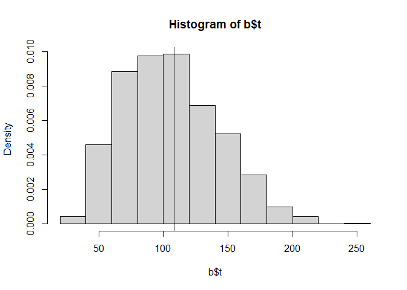

```r
hist(b$t, prob = TRUE)
abline(v = b$t0)
```

## Exercise 7.8

### 解答

```r
rm(list = ls())
library(bootstrap)

n <- nrow(scor)

theta.est <- function(x){
  #估计theta
  v <- eigen(cov(x))$values
  return(max(v) / sum(v))
}

theta.hat <- theta.est(scor)
theta.jack <- sapply(1:n, FUN = function(i) theta.est(scor[-i, ]))

bias <- (n-1) * (mean(theta.jack) - theta.hat)
se <- sqrt(n-1) * sd(theta.jack)

result <- c(theta.hat, bias, se)
names(result) <- c("est", "bias", "se")
result
```

```
##         est        bias          se
## 0.619115038 0.001069139 0.049836277
```

## Exercise 7.11

在例 7.18 中，最佳模型是用留一交叉验证来选出的。 使用留二交叉验证，并比较两个模型。

### 解答

```r
rm(list = ls())
library(DAAG); attach(ironslag)
n <- length(magnetic)
e1 <- e2 <- e3 <- e4 <- numeric(n * (n-1) / 2)

fff <- 1
for(k in 1:(n-1)) for(l in (k+1):n){
  y <- magnetic[-c(k, l)]
  x <- chemical[-c(k, l)]

  J1 <- lm(y ~ x)
  yhat1 <- J1$coef[1] + J1$coef[2] * chemical[c(k, l)]
  e1[fff] <- sum((magnetic[c(k, l)] - yhat1)^2)

  J2 <- lm(y ~ x + I(x^2))
  yhat2 <- J2$coef[1] + J2$coef[2] * chemical[c(k, l)] +
    J2$coef[3] * chemical[c(k, l)]^2
  e2[fff] <- sum((magnetic[c(k, l)] - yhat2)^2)

  J3 <- lm(log(y) ~ x)
  logyhat3 <- J3$coef[1] + J3$coef[2] * chemical[c(k, l)]
  yhat3 <- exp(logyhat3)
  e3[fff] <- sum((magnetic[c(k, l)] - yhat3)^2)

  J4 <- lm(log(y) ~ log(x))
  logyhat4 <- J4$coef[1] + J4$coef[2] * log(chemical[c(k, l)])
  yhat4 <- exp(logyhat4)
  e4[fff] <- sum((magnetic[c(k, l)] - yhat4)^2)

  fff <- fff + 1
}

c(mean(e1), mean(e2), mean(e3), mean(e4))
```

```
## [1] 39.14455 35.74037 36.90983 40.93436
```

最佳模型也是模型 $2$ 。

# HW6

## 课后作业

证明连续情形下 Metropolis-Hastings 算法的平稳性。

### 证明

$r\neq s$ 时，

$$\begin{aligned}
K(s,r) f(s) &= \alpha(s, r) g(r|s) f(s)
\\&= {\rm min}\left\{ \frac{f(r)g(s|r)}{f(s)g(r|s)}, 1 \right\}
g(r|s)f(s)
\\&= {\rm min}\left\{ f(r)g(s|r), f(s)g(r|s) \right\}
\\&= K(r,s)f(r).
\end{aligned}$$

$r = s$ 时， $K(s,r)f(s)$ 与 $K(r,s)f(r)$ 显然相等。 平稳性得证。

## Exercise 8.1

使用置换检验来实现 Cramér-von Mises 两样本等分布检验， 并将其应用于例 8.1 和 8.2 中的数据（chickwts）。

### 解答

```r
rm(list = ls())

cvm.test <- function(x, y){
  m <- length(x); n <- length(y)
  F1 <- ecdf(x); F2 <- ecdf(y)
  w <- sum((F1(x) - F2(x))^2) + sum((F1(y) - F2(y))^2)
  w <- m*n / (m+n)^2 * w
  return(w)
}

cvm.perm <- function(x, y, B){
  z <- c(x, y)
  perm <- numeric(B + 1)
  t0 <- cvm.test(x, y)

  m <- length(x); n <- length(y)

  for(i in 1:B){
    xy <- sample(z)
    x1 <- xy[1:m]; y1 <- xy[-(1:m)]
    perm[i] <- cvm.test(x1, y1)
  }
  perm[B + 1] <- t0

  p <- mean(perm >= t0)
  return(list(t0 = t0, perm = perm, p = p))
}
```

```r
B <- 999
attach(chickwts)
x1 <- as.vector(weight[feed == "soybean"])
x2 <- as.vector(weight[feed == "linseed"])
x3 <- as.vector(weight[feed == "sunflower"])
detach(chickwts)

set.seed(123)

s1 <- cvm.perm(x1, x2, B)
s2 <- cvm.perm(x2, x3, B)
```

```r
s1$p
```

```
## [1] 0.397
```

CvM 检验下，大豆与亚麻籽差异的 $p$ 值并不显著。

```r
s2$p
```

```
## [1] 0.001
```

CvM 检验下，向日葵与亚麻籽差异的 $p$ 值很显著。

## Exercise 8.3

Count 5 等方差检验是基于最大极值点数的。 例 6.15 显示 Count 5 准则不能应用于容量不相等的两样本。 样本容量未必相等时， 基于最大极值点数， 使用置换检验来实现等方差检验。

### 解答

```r
max.ext <- function(x, y){
  x <- x - mean(x); y <- y - mean(y)
  mx <- sum(x > max(y)) + sum(x < min(y))
  my <- sum(y > max(x)) + sum(y < min(x))
  return(max(c(mx, my)))
}

max.ext.perm <- function(x, y, B){
  m <- length(x); n <- length(y)
  s0 <- max.ext(x, y)
  z <- c(x, y)

  perm <- numeric(B + 1)

  for(i in 1:B){
    xy <- sample(z)
    x1 <- xy[1:m]; y1 <- xy[-(1:m)]
    perm[i] <- max.ext(x1, y1)
  }
  perm[B + 1] <- s0

  p <- mean(perm >= s0)

  return(list(s0 = s0, perm = perm, p = p))
}
```

```r
set.seed(123)

x <- rnorm(50)
y <- rnorm(100)

res1 <- max.ext.perm(x, y, 999)
res1$p
```

```
## [1] 0.647
```

两样本的容量不同，方差相同，检验得到的 $p$ 值不显著。

```r
set.seed(456)

x <- rnorm(50)
y <- rnorm(100, sd = 2)

res2 <- max.ext.perm(x, y, 999)
res2$p
```

```
## [1] 0.001
```

两样本的容量不同，方差不同，检验得到的 $p$ 值很显著。

# HW7

## 课后作业

考虑模型

$${\rm P}(Y = 1| X_1,X_2,X_3) = \frac{\exp(a+ b_1X_1 + b_2X_2 + b_3X_3)}{1
+ \exp(a+ b_1X_1 + b_2X_2 + b_3X_3)},$$

其中 $X_1\sim {\rm Poisson}(1), X_2 \sim {\rm Exp}(1), X_3 \sim {\rm Binom}(1,0.5)$ 。

### 解答

```r
rm(list = ls())

a.compute <- function(N, b, f0){
  X1 <- rpois(N, lambda = 1); X2 <- rexp(N); X3 <- rbinom(N, 1, 0.5)

  g <- function(a){
    tt <- exp(- a - b[1] * X1 - b[2] * X2 - b[3] * X3)
    return(mean(1 / (1 + tt)) - f0)
  }
  solution <- uniroot(g,c(-20,0))
  return(solution)
}
```

```r
set.seed(123)
f0 <- c(0.1, 0.01, 0.001, 0.0001)
N <- 1e6; b <- c(0, 2, -1)

res <- lapply(f0, a.compute, N = N, b = b)

a <- sapply(res, function(u) u$root)
result <- rbind(f0 = f0, a = a)
knitr::kable(result, align = "c")
```

| f0 | 0.100000 | 0.010000 | 0.0010 | 0.00010 |
| --- | --- | --- | --- | --- |
| a | -4.974079 | -9.665406 | -14.2569 | -18.60529 |

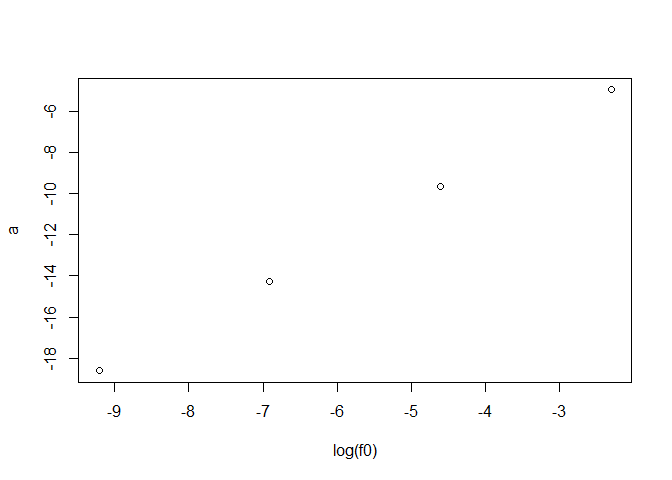

```r
plot(log(f0), a)
```

$a$ 与 $\log f_0$ 大致成线性关系。

## Exercise 9.4

实现一个生成标准 Laplace 分布的随机游走 Metropolis 采样子， 从正态分布模拟增量。 比较不同方差下的提议分布生成的链， 并计算每条链的接受率。

### 解答

对于 Laplace 分布与 Metropolis 采样子， $\alpha(x_i, y) = e^{-|y|} / e^{-|x_i|} = e^{|x_i| - |y|}$ 。

```r
rm(list = ls())

mh.Laplace <- function(N, x0, sigma){
  #N: 链长度| x0: 初值| sigma: 正态分布标准差
  x <- numeric(N + 1); x[1] <- x0
  u <- runif(N)
  num.acc <- 0

  for(i in 2:(N+1)){
    y <- rnorm(1, x[i-1], sigma)
    if(u[i-1] <= exp(abs(x[i-1]) - abs(y))){
      x[i] <- y
      num.acc <- num.acc + 1
    }else x[i] <- x[i-1]
  }

  return(list(chain = x, num.acc = num.acc))
}
```

```r
set.seed(123)
N <- 5000; x0 <- rnorm(1)
sigma <- sqrt(c(0.1, 0.5, 1, 2, 4, 16))

res <- lapply(sigma, mh.Laplace, N = N, x0 = x0)
accept.rate <- sapply(1:6, function(i) res[[i]]$num.acc / N)

result <- rbind(var = sigma^2, accept.rate)
knitr::kable(result, align = "c")
```

| var | 0.1000 | 0.5000 | 1.0000 | 2.0000 | 4.0000 | 16.0000 |
| --- | --- | --- | --- | --- | --- | --- |
| accept.rate | 0.8874 | 0.7724 | 0.7092 | 0.6172 | 0.5348 | 0.3294 |

方差越大，接受率就越小。

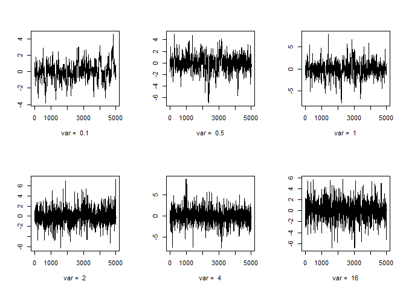

```r
par(mfrow = c(2, 3))
for(i in 1:6) plot(
    res[[i]]$chain, ylab = "", type = "l",
    xlab = paste("var = ", (sigma^2)[i])
  )
```

# HW8

## 课后习题

设 $X_1,...,X_n \sim {\rm Exp}(\lambda)$ 。 出于某种原因，只知道 $X_i$ 落在某个区间 $(u_i, v_i)$ 内， 其中 $u_i<v_i$ 是非随机已知常数。 这种数据被称为区间删失数据。

1. 试直接最大化观测数据的似然函数与使用 EM 算法来求解 $\lambda$ 的 $\rm MLE$ 。 证明 EM 算法收敛于观测数据的 $\rm MLE$ ，且收敛有线性速度。
2. 设 $(u_i,v_i)$ 为 $(11,12), (8,9), (27,28), (13,14), (16,17), (0,1), (23,24), (10,11), (24,25), (2,3)$ 。 试分别编程实现上述两种算法，以得到 $\lambda$ 的 $\rm MLE$ 的数值解。

### 解答

观测数据的似然函数为

$$\begin{aligned}
L(\lambda; X^{(o)})
&= \prod_{i=1}^n {\rm P}_\lambda(u_i\leq X_i \leq v_i)
\\ &= \prod_{i=1}^n (e^{-\lambda u_i} - e^{-\lambda v_i}).
\end{aligned}$$

因此 $\rm MLE$ 满足

$$\sum_{i=1}^n \frac{u_i e^{-\lambda u_i} - v_i e^{-\lambda
v_i}}{e^{-\lambda u_i} - e^{-\lambda v_i}} = 0.$$

难以直接求解，可以数值求解。

给定完整数据 $X^{(o)}, X^{(m)}$ ，

$$\begin{aligned}
I_k(\lambda;X^{(o)})
&= {\rm E}_{\lambda_k} \left[\log L(\lambda; X^{(o)}, X^{(m)})
\big| X^{(o)}\right]
\\&= \sum_{i=1}^n \int_{u_1}^{v_1}\cdots \int_{u_n}^{v_n}
\log(\lambda e^{-\lambda x_i})\lambda_k^n e^{-\lambda_k (x_1+...+x_n)}
{\rm d} x_n \cdots {\rm d}x_1
\\&= \prod_{i=1}^n(e^{-\lambda_k u_i} - e^{-\lambda_k v_i}) \cdot
\sum_{i=1}^n \frac{(e^{-\lambda_k u_i} - e^{-\lambda_k
v_i})\log\lambda - \lambda \left((1/\lambda_k + u_i)e^{-\lambda_k
u_i} - (1/\lambda_k + v_i)e^{-\lambda_k v_i}\right)}{(e^{-\lambda_k
u_i} - e^{-\lambda_k v_i})},
\end{aligned}$$

最大化后得到

$$\lambda_{k+1} =
\left(\frac{1}{\lambda_k} + \frac{1}{n}\sum_{i=1}^n \frac{u_i
e^{-\lambda_k u_i} - v_i e^{-\lambda_k v_i}}{e^{-\lambda_k u_i} -
e^{-\lambda_k v_i}}\right)^{-1}.$$

如果 $\lambda_k$ 收敛到 $\hat\lambda$ ，则

$$\sum_{i=1}^n \frac{u_i e^{-\hat\lambda u_i} - v_i e^{-\hat\lambda
v_i}}{e^{-\hat\lambda u_i} - e^{-\hat\lambda v_i}} = 0.$$
$\hat\lambda$ 就是 $\lambda$ 的 $\rm MLE$ 。

令
$$f(\lambda) = \left(\frac{1}{\lambda} + \frac{1}{n}\sum_{i=1}^n \frac{u_i
e^{-\lambda u_i} - v_i e^{-\lambda v_i}}{e^{-\lambda u_i} - e^{-\lambda
v_i}}\right)^{-1},$$

则 $f$ 单调递增。 $f(\infty) = n / \sum u_i, f(0) = 0$ ，即 $f((0,\infty)) \subset (0, \infty)$ 。 $\exists\ 0 < \alpha < 1$ s.t. $f'(\lambda) < \alpha$ ， $f$ 是 $(0, \infty)$ 上的压缩映射。 因此 $f$ 一定有不动点，且 $\lambda_k$ 收敛到此不动点。

由

$$\frac{1}{\lambda_{k+1}} - \frac{1}{\hat\lambda} = \frac{1}{\lambda_k} -
\frac{1}{\hat\lambda} + \frac{1}{n}\sum_{i=1}^n \frac{u_i e^{-\lambda_k
u_i} - v_i e^{-\lambda_k v_i}}{e^{-\lambda_k u_i} - e^{-\lambda_k v_i}}$$

知

$$\frac{\lambda_{k+1} - \hat\lambda}{\lambda_k - \hat\lambda} =
-1 + \frac{\lambda_{k+1}\hat\lambda}{n\lambda_k} \frac{1}{\hat\lambda}
\cdot \frac{1}{\lambda_k - \hat\lambda}\sum_{i=1}^n \frac{u_i
e^{-\lambda_k u_i} - v_i e^{-\lambda_k v_i}}{e^{-\lambda_k u_i} -
e^{-\lambda_k v_i}}.$$
而

$$\frac{1}{\lambda_k - \hat\lambda}\sum_{i=1}^n \frac{u_i e^{-\lambda_k
u_i} - v_i e^{-\lambda_k v_i}}{e^{-\lambda_k u_i} - e^{-\lambda_k v_i}}$$

的极限为

$$-\frac{1}{\hat\lambda}\sum_{i=1}^n\frac{u_i^2e^{-\hat\lambda u_i} -
v_i^2e^{-\hat\lambda v_i}}{e^{-\hat\lambda u_i} - e^{-\hat\lambda v_i}}
> 0,$$
因此 $\frac{|\lambda_{k+1} - \hat\lambda|}{|\lambda_k - \hat\lambda|}$ 的极限 $< 1$ ， $\lambda_k$ 线性收敛。

EM 算法：

```r
lam.update <- function(lam, u, v){
  uu <- exp(-lam * u) - exp(-lam * v)
  ll <- u * exp(-lam * u) - v * exp(-lam * v)

  ss <- 1 / lam + mean(ll / uu)

  return(1 / ss)
}

lam.em <- function(init, u, v, tol = 1e-5){
  est.old <- init
  est <- lam.update(init, u, v)

  while(abs(est.old - est) > tol){
    est.old <- est
    est <- lam.update(est, u, v)
  }
  return(est)
}

#(11,12), (8,9), (27,28), (13,14), (16,17), (0,1), (23,24), (10,11), (24,25), (2,3)
u <- c(11, 8, 27, 13, 16, 0, 23, 10, 24, 2)
v <- c(12, 9, 28, 14, 17, 1, 24, 11, 25, 3)

MLE1 <- lam.em(1, u, v)
MLE1
```

```
## [1] 0.0719735
```

直接求解：

```r
f <- function(lam, u, v){
  s <- u * exp(-lam * u) - v * exp(-lam *v)
  t <- exp(-lam * u) - exp(-lam *v)
  return(sum(s / t))
}

MLE2 <- uniroot(f, c(1e-3, 1), u = u, v = v, tol = 1e-5)
MLE2$root
```

```
## [1] 0.07197363
```

两种方法的结果一致。

## Exercise 11.8

在 Morra 博弈中，如果收益矩阵的每个元素都减去相同的常数， 或者乘上相同的正常数，则最优策略不变。 但是， simplex 算法可能会在不同的基本可行点（也是最优）停止。 计算 B <- A + 2 ，找到博弈 B 的解， 并验证它是 A 的极值点 (11.12) - (11.15) 之一。 计算 A 和 B 的价值。

### 解答

```r
solve.game <- function(A){
  min.A <- min(A)
  A <- A - min.A
  max.A <- max(A)
  A <- A / max(A)
  m <- nrow(A)
  n <- ncol(A)
  it <- n^3
  a <- c(rep(0, m), 1)
  A1 <- -cbind(t(A), rep(-1, n))
  b1 <- rep(0, n)
  A3 <- t(as.matrix(c(rep(1, m), 0)))
  b3 <- 1
  sx <- simplex(a=a, A1=A1, b1=b1, A3=A3, b3=b3,
      maxi=TRUE, n.iter=it)
  a <- c(rep(0, n), 1)
  A1 <- cbind(A, rep(-1, m))
  b1 <- rep(0, m)
  A3 <- t(as.matrix(c(rep(1, n), 0)))
  b3 <- 1
  sy <- simplex(a=a, A1=A1, b1=b1, A3=A3, b3=b3,
  maxi=FALSE, n.iter=it)
  soln <- list("A" = A * max.A + min.A,
  "x" = sx$soln[1:m],
  "y" = sy$soln[1:n],
  "v" = sx$soln[m+1] * max.A + min.A)
  soln
}

A <- matrix(c(
  0,-2,-2,3,0,0,4,0,0,
  2,0,0,0,-3,-3,4,0,0,
  2,0,0,3,0,0,0,-4,-4,
  -3,0,-3,0,4,0,0,5,0,
  0,3,0,-4,0,-4,0,5,0,
  0,3,0,0,4,0,-5,0,-5,
  -4,-4,0,0,0,5,0,0,6,
  0,0,4,-5,-5,0,0,0,6,
  0,0,4,0,0,5,-6,-6,0), 9, 9)

library(boot)
B <- A + 2
s <- solve.game(B)
```

```r
round(cbind(s$x, s$y), 5)
```

```
##       [,1]    [,2]
## x1 0.00000 0.00000
## x2 0.00000 0.00000
## x3 0.40984 0.40984
## x4 0.00000 0.00000
## x5 0.32787 0.32787
## x6 0.00000 0.00000
## x7 0.26230 0.26230
## x8 0.00000 0.00000
## x9 0.00000 0.00000
```

simplex 算法在极值点 (11.15) 处停止了。

```r
s$v
```

```
## x10
##   2
```

B 的价值为 $2$ ，A 的价值为 $0$ 。

# HW9

## 2.1.3 Exercise 4

为什么要使用 $\texttt{unlist()}$ 来将列表转换为原子向量， $\texttt{as.vector()}$ 不行？

### 解答

因为列表也属于向量， $\texttt{as.vector()}$ 不会改变结果。 所以需要使用 $\texttt{unlist()}$ 。

## 2.3.1 Exercise 1

$\texttt{dim()}$ 作用于向量后，会返回什么？

### 解答

会返回 $\texttt{NULL}$ 。

```r
a <- c(1, 2, 3)
dim(a)
```

[output not shown]

## 2.3.2 Exercise 2

如果 $\texttt{is.matrix(x)}$ 是 $\texttt{TRUE}$ ， $\texttt{is.array(x)}$ 会返回什么？

### 解答

也返回 $\texttt{TRUE}$ 。

```r
x <- matrix(0, 2, 2)
c(is.matrix(x), is.array(x))
```

```
## [1] TRUE TRUE
```

## 2.4.5 Exercise 2

$\texttt{as.matrix()}$ 作用于各列类型不同的 data frame ， 会发生什么？

### 解答

如果各列是不同精度的数值，则会将每个元素转换为当前最高精度。

如果是数值与字符混合，则转换为字符。

如果某列含列表，则转换为列表。

## 2.4.5 Exercise 3

data frame 能不能只有 $0$ 行？列？

### 解答

都可以。

```r
m <- matrix(0, 2, 2)
m <- m[FALSE, FALSE]
m
```

```
## <0 x 0 matrix>
```

## 11.1.2 Exercises 2

以下函数能把向量缩放至范围在 $[0,1]$ 内。

```r
scale01 <- function(x) {
  rng <- range(x, na.rm = TRUE)
  (x - rng[1]) / (rng[2] - rng[1])
}
```

如何将其作用于 data frame 的每一列？ 作用于 data frame 的每一数值列？

### 解答

```r
x <- as.data.frame(matrix(rnorm(9), 3, 3)); x
```

```
##           V1         V2         V3
## 1 -0.2234777 0.58332722 -0.4127342
## 2  0.1471969 0.97033779 -0.4155289
## 3 -0.2258047 0.04723656  0.5315547
```

```r
y <- apply(x, 2, scale01); y
```

```
##               V1        V2          V3
## [1,] 0.006238442 0.5807496 0.002950858
## [2,] 1.000000000 1.0000000 0.000000000
## [3,] 0.000000000 0.0000000 1.000000000
```

```r
x <- cbind(x, s = c("a", "b", "c")); x
```

```
##           V1         V2         V3 s
## 1 -0.2234777 0.58332722 -0.4127342 a
## 2  0.1471969 0.97033779 -0.4155289 b
## 3 -0.2258047 0.04723656  0.5315547 c
```

```r
y <- apply(x, 2, function(u) if(is.numeric(u)) scale01(u) else u); y
```

```
##      V1           V2           V3           s
## [1,] "-0.2234777" "0.58332722" "-0.4127342" "a"
## [2,] " 0.1471969" "0.97033779" "-0.4155289" "b"
## [3,] "-0.2258047" "0.04723656" " 0.5315547" "c"
```

## 11.2.5 Exercise 1

使用 $\texttt{vapply()}$ 来：

- 1. 计算数值 data frame 每一列的标准差。
- 2. 计算混合 data frame 每一数值列的标准误差。

### 解答

```r
x <- as.data.frame(matrix(rnorm(9), 3, 3)); x
```

```
##            V1        V2         V3
## 1  0.01339598 0.3407015 -0.4730226
## 2 -0.48611715 0.4801454  1.1039945
## 3 -0.93384355 0.3496477  0.3663240
```

```r
y <- vapply(x, sd, numeric(1)); y
```

```
##        V1        V2        V3
## 0.4738556 0.0780537 0.7890546
```

```r
x <- cbind(x, s = c("a", "b", "c")); x
```

```
##            V1        V2         V3 s
## 1  0.01339598 0.3407015 -0.4730226 a
## 2 -0.48611715 0.4801454  1.1039945 b
## 3 -0.93384355 0.3496477  0.3663240 c
```

```r
y <- vapply(
  x[vapply(x, is.numeric, logical(1))],
  sd, numeric(1)
)
y
```

```
##        V1        V2        V3
## 0.4738556 0.0780537 0.7890546
```

## Exercise 9.8

考虑二元密度

$$f(x, y) \propto \binom{n}{x} y^{x+a-1}(1-y)^{n-x+b-1}, \ x=0,1,...,n, \
0\leq y\leq 1.$$

固定 $a, b, n$ ，条件分布为 ${\rm Binom}(n,y)$ 与 ${\rm Beta}(x+a, n-x+b)$ 。 使用 Gibbs 采样来逼近此密度。

- 编写一个 R 函数
- 编写一个 Rcpp 函数
- 使用函数 $\texttt{microbenchmark}$ 来比较两个函数的计算时间。

### 解答

R 函数：

```r
gibbs_r <- function(a, b, n, N){
  X <- matrix(0, N, 2)

  for(i in 2:N){
    X[i, 1] <- rbinom(1, n, X[i-1, 2])
    X[i, 2] <- rbeta(1, X[i, 1] + a, n - X[i, 1] + b)
  }

  colnames(X) <- c("x", "y")
  return(X)
}
```

Rcpp 函数：

```r
library(Rcpp)

cppFunction('
NumericMatrix gibbs_rcpp(double a, double b, int n, int N){
  NumericMatrix X(N, 2);

  for(int i = 1; i < N; i++){
    X(i, 0) = R::rbinom(n, X(i-1, 1));
    X(i, 1) = R::rbeta(X(i, 0) + a, n - X(i, 0) + b);
  }

  return X;
}
')
```

计算时间对比：

```r
library(microbenchmark)
a <- 3; b <- 4; n <- 20; N <- 1e4

microbenchmark(gibbs_r(a, b, n, N), gibbs_rcpp(a, b, n, N))
```

```
## Unit: milliseconds
##                    expr     min       lq     mean   median       uq     max
##     gibbs_r(a, b, n, N) 21.7100 28.02565 34.99988 34.66845 40.45740 59.2577
##  gibbs_rcpp(a, b, n, N)  1.8259  2.00610  2.14381  2.09545  2.23045  3.6194
##  neval cld
##    100  a
##    100   b
```

Rcpp 函数的效率要高得多。